# Tidying messy Excel data (tidyxl)

Abhijit Dasgupta

2018-05-02

Well, here’s what I was dealing with:

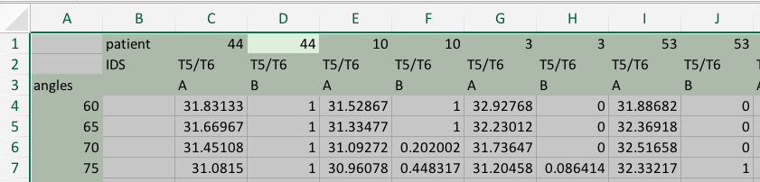

(You can download this dataset for your playtime [here](https://drive.google.com/file/d/1ekffJQOB_p8sS7bxEBaPUHCesmFoi7s7/view?usp=sharing))

Notice that we have 3 header rows, first with patient IDs, second with spine region, and third with variable names (A and B, to protect the innocent).

#### Goal

A dataset that, for each patient and each angle gives us corresponding values of A and B. So this would be a four-column data set with ID, angle, A and B.

## Attempt 1 (readxl)

```r
d1 <- readxl::read_excel('spreadsheet1.xlsx')
head(d1)
```

```
## # A tibble: 6 x 26
##   X__1  patient `44`  `44__1` `10`  `10__1` `3`   `3__1` `53`  `53__1`
##   <chr> <chr>   <chr> <chr>   <chr> <chr>   <chr> <chr>  <chr> <chr>
## 1 <NA>  IDS     T5/T6 T5/T6   T5/T6 T5/T6   T5/T6 T5/T6  T5/T6 T5/T6
## 2 angl… <NA>    A     B       A     B       A     B      A     B
## 3 60    <NA>    31.8… 1       31.5… 1       32.9… 0      31.8… 0
## 4 65    <NA>    31.6… 1       31.3… 1       32.2… 0      32.3… 0
## 5 70    <NA>    31.4… 1       31.0… 0.2020… 31.7… 0      32.5… 0
## 6 75    <NA>    31.0… 1       30.9… 0.4483… 31.2… 8.641… 32.3… 1
## # ... with 16 more variables: `2` <chr>, `2__1` <chr>, `8` <chr>,
## #   `8__1` <chr>, `6` <chr>, `6__1` <chr>, `43` <chr>, `43__1` <chr>,
## #   `48` <chr>, `48__1` <chr>, `46` <chr>, `46__1` <chr>, `4` <chr>,
## #   `4__1` <chr>, `9` <chr>, `9__1` <chr>
```

This strategy gives us funky column names, and pushes two of the headers into data rows. Since the headers are in rows, they’re a little harder to extract and work with. More worrisome is the fact that since the headers leaked into the data rows, the columns are all of type `character` rather than type `numeric`, which would now require further careful conversion after cleaning. So I don’t think `readxl` is the way to go here, if there’s a better solution.

## Attempt 2 (tidyxl)

```r
d2 <- tidyxl::xlsx_cells('spreadsheet1.xlsx')
head(d2)
```

```
## # A tibble: 6 x 21
##   sheet address   row   col is_blank data_type error logical numeric
##   <chr> <chr>   <int> <int> <lgl>    <chr>     <chr> <lgl>     <dbl>
## 1 T5T6  B1          1     2 FALSE    character <NA>  NA           NA
## 2 T5T6  C1          1     3 FALSE    numeric   <NA>  NA           44
## 3 T5T6  D1          1     4 FALSE    numeric   <NA>  NA           44
## 4 T5T6  E1          1     5 FALSE    numeric   <NA>  NA           10
## 5 T5T6  F1          1     6 FALSE    numeric   <NA>  NA           10
## 6 T5T6  G1          1     7 FALSE    numeric   <NA>  NA            3
## # ... with 12 more variables: date <dttm>, character <chr>,
## #   character_formatted <list>, formula <chr>, is_array <lgl>,
## #   formula_ref <chr>, formula_group <int>, comment <chr>, height <dbl>,
## #   width <dbl>, style_format <chr>, local_format_id <int>
```

The `xlsx_cells` captures the data in a tidy fashion, explicitly calling out rows and columns and other metadata within each cell. We can clean up this data using tidyverse functions:

```r
library(tidyverse)
cleanData1 <- function(d) {
  angle <- d %>% filter(row >= 4, col == 1) %>% pull(numeric)
  name <- d %>% filter(row %in% c(1,3), col >= 3) %>%
    mutate(character = ifelse(is.na(character),
                              as.character(numeric),
                              character)) %>%
    select(row, col, character) %>%
    filter(!is.na(character)) %>%
    spread(row, character) %>%
    unite(ID, `1`:`3`, sep = '_') %>%
    pull(ID)
  data <- d %>% filter(row >= 4, col >= 3) %>%
    filter(!is.na(numeric)) %>%
    select(row, col, numeric) %>%
    spread(col, numeric) %>%
    select(-row) %>%
    set_names(name) %>%
    cbind(angle) %>%
    gather(variable, value, -angle) %>%
    separate(variable, c('ID','Measure'), sep = '_') %>%
    spread(Measure, value) %>%
    select(ID, angle, A, B) %>%
    arrange(ID, angle)
  return(data)
}

head(cleanData1(d2))
```

```
##   ID angle        A        B
## 1 10    60 31.52867 1.000000
## 2 10    65 31.33477 1.000000
## 3 10    70 31.09272 0.202002
## 4 10    75 30.96078 0.448317
## 5 10    80 30.79397 0.670876
## 6 10    85 30.52185 0.461406
```

This is a lot of data munging, and though `dplyr` is powerful, it took a lot of trial and error to get the final pipeline done.

Nonetheless, I was really psyched about `tidyxl`, since it automated a job that would have taken manual manipulation (I had 12 spreadsheets like this to process). I was going to write a blog post on this cool package that made my life dealing with messy Excel file a piece of cake. But wait, there’s more…

## Attempt 3 (tidyxl + unpivotr)

```r
# devtools::install_github('nacnudus/unpivotr')
library(unpivotr)

cleanData2 <- function(d){
  bl <- d %>% select(row, col, data_type, numeric, character) %>%
    behead('N', ID) %>%
    behead('N', spine) %>%
    behead('N', variable)
  # Extract the angles column
  bl1 <- bl %>% filter(variable == 'angles') %>% spatter(variable) %>%
    select(row, angles)
  # Extract the rest of the columns
  bl2 <- bl %>% filter(variable %in% c('A','B')) %>% select(-spine, -col) %>%
    spatter(ID) %>% # Spread to columns
    select(-character) %>% # All my variables are numeric
    gather(ID, value, -row, -variable) %>%
    spread(variable, value)
  final <- bl1 %>% left_join(bl2) %>% # put things back together
    arrange(ID, angles) %>%
    select(ID, everything(),-row) # re-arrange columns
  return(final)
}

cleanData2(d2)
```

```
## # A tibble: 588 x 4
##    ID    angles     A     B
##    <chr>  <dbl> <dbl> <dbl>
##  1 10        60  31.5 1
##  2 10        65  31.3 1
##  3 10        70  31.1 0.202
##  4 10        75  31.0 0.448
##  5 10        80  30.8 0.671
##  6 10        85  30.5 0.461
##  7 10        90  30.3 0.245
##  8 10        95  30.0 0.159
##  9 10       100  29.7 0.170
## 10 10       105  29.2 0.421
## # ... with 578 more rows
```

In this example, I’m using the `behead` function (available in the development version of `unpivotr` on GitHub) to extract out the three rows of headers. Then I’m extracting out the `angles` column separately and merging it with the rest of the columns.

> In case you’re wondering about the “N” in the `behead` code, `unpivotr` has a geographic options system as to where the headers are with respect to the main code. This [vignette](https://nacnudus.github.io/unpivotr/articles/compass-directions.html) explains this nomenclature.

## Attempt 4 (tidyxl + unpivotr)

After re-reading the `unpivotr` documentation, I realized that the `angles` column could be treated as a row header in the `unpivotr` code. So I further modified the function:

```r
cleanData3 <- function(d) {
  final <- d %>%
    select(row, col, data_type, numeric, character) %>%
    behead('N', ID) %>%  # Extract column headers
    behead('N', spine) %>%
    behead('N', variable) %>%
    behead('W', angles) %>% # angles as row header
    select(numeric, ID:angles, data_type, -spine) %>% # all vars are numeric
    filter(variable %in% c('A', 'B')) %>% # Kills off some extra columns
    spatter(variable) # Spreads, using data_type, numeric
  return(final)
}

cleanData3(d2)
```

```
## # A tibble: 588 x 4
##    ID    angles     A     B
##    <chr>  <dbl> <dbl> <dbl>
##  1 10        60  31.5 1
##  2 10        65  31.3 1
##  3 10        70  31.1 0.202
##  4 10        75  31.0 0.448
##  5 10        80  30.8 0.671
##  6 10        85  30.5 0.461
##  7 10        90  30.3 0.245
##  8 10        95  30.0 0.159
##  9 10       100  29.7 0.170
## 10 10       105  29.2 0.421
## # ... with 578 more rows
```

I get to the same output, but with much cleaner code. This is cool!!

I’m going to go deeper into the `unpivotr` documentation and see what else can be in my regular pipeline. A big thank you to the tool-makers that create these tools that make everyday activies easier and make us stay saner.